# Cómo comparar la calidad de dos archivos

J. Ignacio Lucas Lledó

2023-06-05

En el guión se pregunta cuál de dos archivos FASTQ contiene lecturas de mayor calidad. El objetivo es simplemente comprobar que las lecturas producidas en los dos sentidos tienen calidades comparables, o si por el contrario las lecturas primeras (*forward*) són en promedio de mayor o menor calidad que las lecturas segundas (*reverse*).

Primero leemos los archivos y generamos el informe de calidad:

```r
library('ShortRead')
ResumenCalidad <- qa('data', type = 'fastq', pattern = '*.fastq')
```

La calidad está definida para cada base de cada lectura, lo que supone una cantidad de datos muy grande. El informe nos presenta diferentes formas de resumirlos. El componente `readQualityScore` del objeto `ResumenCalidad` es un marco de datos que contiene la distribución de calidades *medias* por lectura. Es decir, en cada archivo (o *lane* en el marco de datos) a cada una de las 65135 lecturas se le asigna la calidad media de todas sus bases, y la tabla recoge la *densidad* de estos valores medios, en cada archivo. Es como un histograma con incrementos muy finos. Nos sirve para representar la distribución de calidades medias.

Podemos utilizar la función `plot()` de R. Para facilitar las cosas, separaré los datos de uno y otro archivo en dos objetos diferentes.

```r
# Para facilitar la manipulación, extraigo la tabla que me interesa en un objeto indpendiente:
z <- ResumenCalidad[['readQualityScore']]
head(z)
```

```
##    quality      density               lane type
## 1 25.74965 9.555937e-07 ERR4423464_1.fastq read
## 2 25.77390 2.355761e-06 ERR4423464_1.fastq read
## 3 25.79816 5.224609e-06 ERR4423464_1.fastq read
## 4 25.82242 1.043612e-05 ERR4423464_1.fastq read
## 5 25.84668 1.880162e-05 ERR4423464_1.fastq read
## 6 25.87094 3.060406e-05 ERR4423464_1.fastq read
```

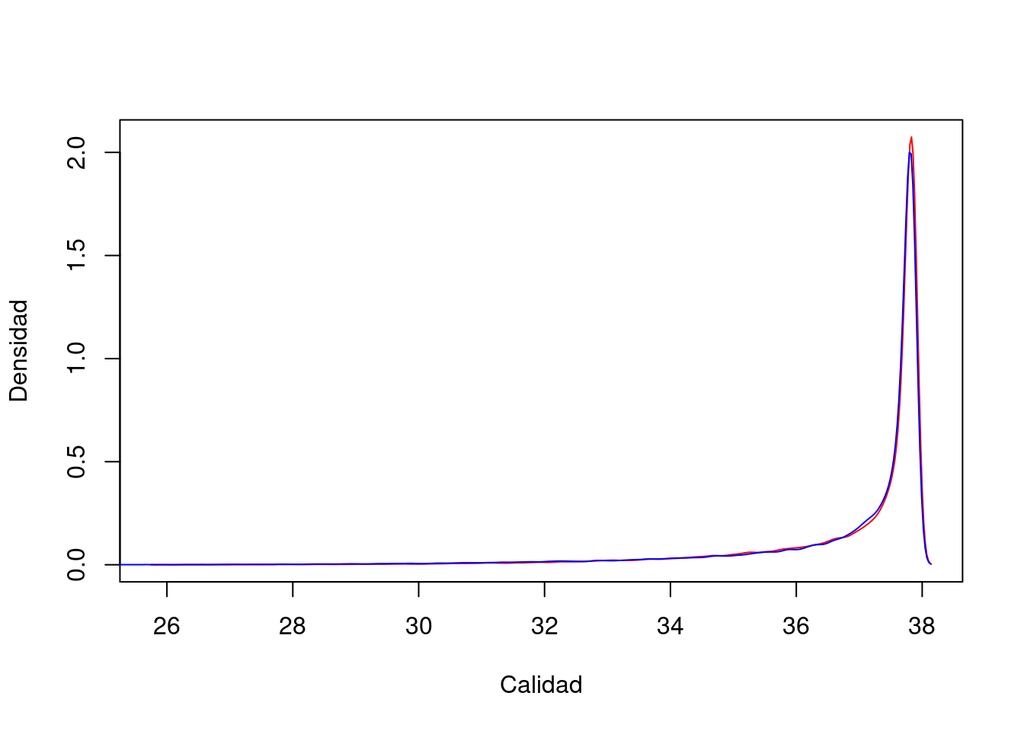

```r
# Extraigo las filas de "z" donde "lane" tiene un valor u otro:
Archivo1 <- z[z$lane == 'ERR4423464_1.fastq', ]
Archivo2 <- z[z$lane == 'ERR4423464_2.fastq', ]
plot(Archivo1$quality, Archivo1$density, type = 'l', col = 'red', xlab = 'Calidad', ylab = 'Densidad')
lines(Archivo2$quality, Archivo2$density, col = 'blue')
```

La misma gráfica se puede obtener más fácilmente a partir del objeto `z` directamente si usamos el paquete `ggplot2`, pero su uso es más avanzado:

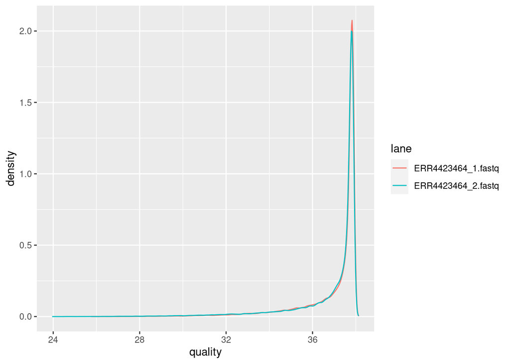

```r
library(ggplot2)
ggplot(data = z, mapping = aes(x = quality, y = density, color = lane)) + geom_line()
```

De cualquier manera, nos convencemos de que la distribución de calidades medias es tan similar entre los dos archivos que resulta difícil distinguir las dos líneas de sus distribuciones. Esto bastaría para contestar la pregunta del guión.

## Usando la tabla `baseQuality`

Podemos llegar a la misma conclusión usando la tabla `baseQuality`. El problema aquí es que la calidad no está descodificada (muestra los signos ASCII, en lugar de su valor numérico), lo que dificulta ligeramente la operación. Una rápida búsqueda por internet nos sugiere que podemos encontrar la posición del símbolo ASCII con la función `charToRaw()`. Aunque hace falta combinarla con `as.numeric()` para expresar el resultado en sistema decimal. Además necesitamos recordar que los archivos FASTQ codifican la calidad de las bases con los símbolos ASCII a partir del símbolo “!”, que está en la posición 33. Es decir, tenemos que restar 33 para obtener la calidad en escala Phred:

```r
# Extraemos la tabla a un objeto diferente, que podamos manipular mejor.
baseQuality <- ResumenCalidad[['baseQuality']]
# Añadimos una columna, con el valor numérico en escala Phred:
baseQuality$qual <- sapply(baseQuality$score, function(x) as.numeric(charToRaw(x))) - 33
head(baseQuality)
```

```
##   score count               lane qual
## 1           0 ERR4423464_1.fastq   -1
## 2     !     0 ERR4423464_1.fastq    0
## 3     "     0 ERR4423464_1.fastq    1
## 4     #    33 ERR4423464_1.fastq    2
## 5     $     0 ERR4423464_1.fastq    3
## 6     %     0 ERR4423464_1.fastq    4
```

La tabla `baseQuality` contiene la frecuencia absoluta (`count`) de cada valor de calidad (`qual`) en cada archivo (`lane`). Tal vez es más fácil separar los dos datos de los dos archivos en dos tablas diferentes:

```r
calidades1 <- baseQuality[baseQuality$lane == 'ERR4423464_1.fastq', ]
calidades2 <- baseQuality[baseQuality$lane == 'ERR4423464_2.fastq', ]
```

Ahora, la calidad media de cada archivo se obtiene usando las frecuencias absolutas de los valores de calidad, de acuerdo con la definición de la media.

```r
QMedia1 <- sum(calidades1$count * calidades1$qual) / sum(calidades1$count)
QMedia1
```

```
## [1] 37.00021
```

```r
QMedia2 <- sum(calidades2$count * calidades2$qual) / sum(calidades2$count)
QMedia2
```

```
## [1] 36.8436
```

La calidad media de las bases del archivo `ERR4423464_2.fastq es`, por lo tanto, muy ligeramente inferior a la calidad media de las bases en el archivo `ERR4423464_1.fastq`.

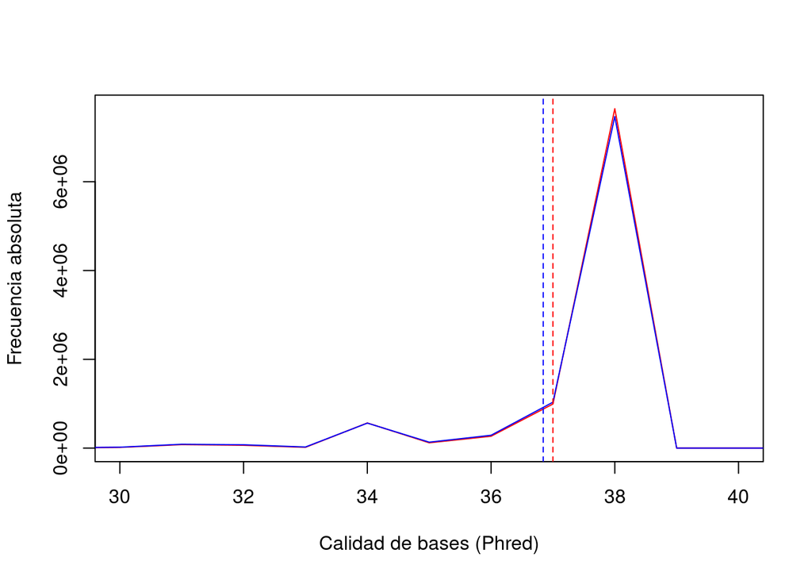

```r
plot(calidades1$qual, calidades1$count, type = 'l', col = 'red', xlim = c(30, 40),
     xlab = 'Calidad de bases (Phred)', ylab = 'Frecuencia absoluta')
lines(calidades2$qual, calidades2$count, type = 'l', col = 'blue')
abline(v = QMedia1, lty = 2, col = 'red')
abline(v = QMedia2, lty = 2, col = 'blue')
```

En cualquier caso, nos ha resultado incómodo trabajar con los datos del informe generado por la función `qa()`. Además, algunos detalles quedan completamente inaccesibles: el emparejamiento de las lecturas de uno y otro archivo. Cuando comparamos dos conjuntos de datos, no es lo mismo comparar las medias globalmente que comparar datos emparejados. Si realizamos una comparación lectura a lectura, tenemos un poder estadístico mucho mayor para rechazar la hipótesis nula de que las lecturas tienen la misma calidad media en los dos archivos.

## Trabajando directamente con las lecturas

Vamos a aprovechar el hecho de que los archivos FASTQ con los que estamos trabajando son muy pequeños. Los podemos leer con la función `readFastq()` y tener toda su información en la memoria de trabajo.

```r
R1 <- readFastq('data/ERR4423464_1.fastq')
R2 <- readFastq('data/ERR4423464_2.fastq')

# Calidades de la primera lectura en R1:
quality(R1)[[1]]
```

```
## 184-letter BString object
## seq: CCCCCGGGGGGGGGGGGGGGGGGGGGGGGGGGGGGG...GGGGGGGGGGGGGGGGGGGGGGGGFGGGGGGGGGGF
```

```r
# Codificación de calidades en R1:
encoding(quality(R1))
```

```
##  !  "  #  $  %  &  '  (  )  *  +  ,  -  .  /  0  1  2  3  4  5  6  7  8  9  :
##  0  1  2  3  4  5  6  7  8  9 10 11 12 13 14 15 16 17 18 19 20 21 22 23 24 25
##  ;  <  =  >  ?  @  A  B  C  D  E  F  G  H  I  J  K  L  M  N  O  P  Q  R  S  T
## 26 27 28 29 30 31 32 33 34 35 36 37 38 39 40 41 42 43 44 45 46 47 48 49 50 51
##  U  V  W  X  Y  Z  [ \\  ]  ^  _  `  a  b  c  d  e  f  g  h  i  j  k  l  m  n
## 52 53 54 55 56 57 58 59 60 61 62 63 64 65 66 67 68 69 70 71 72 73 74 75 76 77
##  o  p  q  r  s  t  u  v  w  x  y  z  {  |  }  ~
## 78 79 80 81 82 83 84 85 86 87 88 89 90 91 92 93
```

```r
# Transformación de las calidades de la primera lectura a vector:
as.vector(quality(R1)[[1]])
```

```
##   [1] "C" "C" "C" "C" "C" "G" "G" "G" "G" "G" "G" "G" "G" "G" "G" "G" "G" "G"
##  [19] "G" "G" "G" "G" "G" "G" "G" "G" "G" "G" "G" "G" "G" "G" "G" "G" "G" "G"
##  [37] "G" "G" "G" "G" "G" "G" "G" "G" "G" "G" "G" "G" "G" "G" "G" "G" "G" "G"
##  [55] "G" "G" "G" "G" "G" "G" "G" "F" "G" "G" "G" "G" "G" "G" "G" "G" "G" "G"
##  [73] "G" "G" "G" "G" "G" "G" "G" "G" "G" "G" "G" "G" "G" "G" "G" "G" "G" "G"
##  [91] "G" "G" "G" "G" "G" "G" "G" "G" "G" "G" "G" "G" "G" "F" "G" "G" "G" "G"
## [109] "G" "G" "G" "G" "G" "G" "G" "G" "G" "G" "G" "G" "F" "G" "G" "G" "G" "G"
## [127] "G" "G" "G" "G" "G" "G" "G" "G" "G" "G" "G" "G" "G" "G" "G" "G" "G" "G"
## [145] "G" "G" "G" "G" "G" "G" "G" "G" "G" "G" "G" "G" "G" "G" "G" "G" "G" "G"
## [163] "G" "G" "G" "G" "G" "G" "G" "G" "G" "G" "F" "G" "G" "G" "G" "G" "G" "G"
## [181] "G" "G" "G" "F"
```

```r
# Uso de la codificación a modo de "descodificador":
encoding(quality(R1))[as.vector(quality(R1)[[1]])]
```

```
##  C  C  C  C  C  G  G  G  G  G  G  G  G  G  G  G  G  G  G  G  G  G  G  G  G  G
## 34 34 34 34 34 38 38 38 38 38 38 38 38 38 38 38 38 38 38 38 38 38 38 38 38 38
##  G  G  G  G  G  G  G  G  G  G  G  G  G  G  G  G  G  G  G  G  G  G  G  G  G  G
## 38 38 38 38 38 38 38 38 38 38 38 38 38 38 38 38 38 38 38 38 38 38 38 38 38 38
##  G  G  G  G  G  G  G  G  G  F  G  G  G  G  G  G  G  G  G  G  G  G  G  G  G  G
## 38 38 38 38 38 38 38 38 38 37 38 38 38 38 38 38 38 38 38 38 38 38 38 38 38 38
##  G  G  G  G  G  G  G  G  G  G  G  G  G  G  G  G  G  G  G  G  G  G  G  G  G  F
## 38 38 38 38 38 38 38 38 38 38 38 38 38 38 38 38 38 38 38 38 38 38 38 38 38 37
##  G  G  G  G  G  G  G  G  G  G  G  G  G  G  G  G  F  G  G  G  G  G  G  G  G  G
## 38 38 38 38 38 38 38 38 38 38 38 38 38 38 38 38 37 38 38 38 38 38 38 38 38 38
##  G  G  G  G  G  G  G  G  G  G  G  G  G  G  G  G  G  G  G  G  G  G  G  G  G  G
## 38 38 38 38 38 38 38 38 38 38 38 38 38 38 38 38 38 38 38 38 38 38 38 38 38 38
##  G  G  G  G  G  G  G  G  G  G  G  G  G  G  G  G  F  G  G  G  G  G  G  G  G  G
## 38 38 38 38 38 38 38 38 38 38 38 38 38 38 38 38 37 38 38 38 38 38 38 38 38 38
##  G  F
## 38 37
```

```r
# Calidad media de las bases de la primera lectura:
mean(encoding(quality(R1))[as.vector(quality(R1)[[1]])])
```

```
## [1] 37.86413
```

Podemos acceder a las calidades de cada base de cada lectura, de cada archivo, y traducir los símbolos a su valor numérico usando la codificación propia de estos datos. Mediante la función `sapply()` podemos crear un vector con las calidades medias de todas las lecturas de cada archivo.

```r
# Esto tarda un poquito en ejecutarse. La función sapply() ejecuta una
# función (definida ahí mismo) para cada valor de x en un vector o lista:
QMediaPorLectura1 <- sapply(1:length(R1),
    function(x) mean(encoding(quality(R1))[as.vector(quality(R1)[[x]])]))
mean(QMediaPorLectura1)
```

```
## [1] 36.9713
```

```r
weighted.mean(QMediaPorLectura1, width(R1))
```

```
## [1] 37.00021
```

```r
QMediaPorLectura2 <- sapply(1:length(R2),
    function(x) mean(encoding(quality(R2))[as.vector(quality(R2)[[x]])]))
mean(QMediaPorLectura2)
```

```
## [1] 36.8644
```

```r
weighted.mean(QMediaPorLectura2, width(R2))
```

```
## [1] 36.8436
```

Observa que las calidades medias por archivo coinciden con las que habíamos calculado antes (a partir de las frecuencias de cada calidad) sólo si ponderamos cada lectura por su longitud, como cabía esperar.

Ahora que tenemos los datos brutos de calidad por secuencia, podemos realizar un test estadístico. Observa la diferencia entre estos dos:

```r
t.test(QMediaPorLectura1, QMediaPorLectura2)
```

```
##
##  Welch Two Sample t-test
##
## data:  QMediaPorLectura1 and QMediaPorLectura2
## t = 11.774, df = 127831, p-value < 2.2e-16
## alternative hypothesis: true difference in means is not equal to 0
## 95 percent confidence interval:
##  0.08910168 0.12469242
## sample estimates:
## mean of x mean of y
##   36.9713   36.8644
```

```r
t.test(QMediaPorLectura1, QMediaPorLectura2, paired = TRUE)
```

```
##
##  Paired t-test
##
## data:  QMediaPorLectura1 and QMediaPorLectura2
## t = 27.831, df = 65134, p-value < 2.2e-16
## alternative hypothesis: true mean difference is not equal to 0
## 95 percent confidence interval:
##  0.0993687 0.1144254
## sample estimates:
## mean difference
##        0.106897
```

Es decir, cada lectura en sentido directo (*forward*, en `R1`) tiene una calidad en término medio 0.106897 unidades Phred superior a la lectura correspondiente en sentido inverso. Podríamos haber caracterizado cada lectura por una medida diferente de calidad, como el número esperado de errores, o la suma de las calidades de sus bases (en lugar de su media). No está de más recordar que la calidad en escala Phred és $-10$ veces el logaritmo en base 10 de la probabiliad de que la base sea errónea. Esto implica que la media de las calidades ya no tiene una interpretación fácil en términos de probabilidad de error, porque la media aritmética de los logaritmos de unos cuantos números no es igual al logaritmo de la media aritmética de esos números. Pero esa es otra historia, y en algún punto hay que cortar.